# An Analysis of Toronto Transit Commission (TTC) Bus Delay Data 2020

Alice Huang

# Importance of TTC Bus Service in Toronto

The TTC (Toronto Transit Commission) has served the citizens of Toronto for over 100 years, and to date, has transported more than 31 billion riders to school, work, shopping, entertainment, and more destinations. Millions of people rely on the TTC to travel around Toronto.

Public transit provides many benefits to citizens of metropolitan cities. For example:

1. Public transit is more efficient at transporting large numbers of people at once and can reduce traffic congestion on busy roads.
2. Public transit is more environmentally friendly than driving, as passengers can share the carbon footprint of vehicle emissions, and emit less pollution per capita.
- Fun Fact: In 2020, the TTC had the largest fleet of electric buses in North America
3. Public transit is cheaper for riders. Riders and governments share the costs of vehicle maintenance, insurance, and fuel. Public transit is especially useful for low-income riders and allows them to access more opportunities for education, employment, and social mobility.

Toronto is considered to have one of the best public transit systems in North America. This may surprise riders who lament the lack of subway coverage in comparison to Paris or Tokyo. However, this designation is due to the extensive network of buses which provide frequent service and cover many parts of the city. Many Torontonians’ homes are less than a 15 minute walk away from a bus stop, subway station or streetcar. Many streets have buses that come in 10 minutes or less during rush hour. For riders who do not live downtown or do not travel downtown, the bus is the backbone of public transit. Buses are a key component of public transit in Toronto.

Given the importance of efficient public transit in Toronto, it is important to learn about the frequency and length of bus delays in order to guarantee smoothness of operations and better rider experience in the future.

# Objectives

In this report we will address the following questions:

1. Which bus routes have the most delays?
2. Does direction of travel affect the delay time of buses?
3. What are the most common causes of TTC bus delays?
4. On average, what bus delay time can a rider expect given a specific incident (eg. collision, emergency services)?

# Source of Data

The 2020 TTC bus delay data on which this report was based was downloaded from the City of Toronto Open Data Portal (https://open.toronto.ca/dataset/ttc-bus-delay-data/) in January 2022. This data was published by the Toronto Transit Commission and was last updated on October 21, 2021. The data is in a XLSX file with different sheets for different months of the year 2020.

# Cleaning the Data

I noticed that for some months, the `Route` number of the bus was double format while in others, it was character format. So I made all the route numbers double format for consistency. For some months, the `Time` column, which denoted the time the delay started, was entered in character format while in others, it was entered as a `double (S3: POSIXct, POSIXt)` type in R. All times were converted to the `double (S3: POSIXct, POSIXt)` type for consistency.

The data from the different Excel sheets for the different months were combined into 1 large sheet.

For some months, the delay time in minutes was entered in a column called `Delay`, while in other months, it was entered in a column called `Min Delay`. I assumed that both columns contained the delay time in minutes though the readme file only had instructions for `Min Delay` column. I made a new column called `Delay_Time` that combined the data from the two columns, and removed the `Delay` and `Min Delay` columns. Unfortunately, a few Delay Times were entered as 0. Since it didn’t make sense for a bus to be delayed by 0 minutes, instances with delay time 0 were removed.

## Ensuring Consistency of Spellings and Capitalizations

There were MANY inconsistencies in the spellings and capitalizations of the recorded locations of the buses. For example, Scarborough Centre Station was entered as “SCARBOROUGH CENTRE STA”, “Scarborough Town Centre”, “Scarborough Centre STN”, “Scarborough Town Center”, just to name a few. All Locations were changed to all caps to ensure consistency in capitalization. They will also follow the same spelling on the TTC website (https://ttc.ca/routes-and-schedules#/). Many common words occurring in location names like “Station” and “Ellesmere” were changed to the correct spelling. Analysis on Locations of Delays is a work in progress, and some locations are still entered inconsistently and/or spelled incorrectly. I hope to continue further processing the data so that the location names can be as consistent as possible. So far I have merged close to 1000 alternate spellings and capitalizations into the appropriate groups.

The Locations data still needs to be cleaned up a lot. There are still inconsistencies in the entry of Locations.

## Ensuring Consistency in Incident Descriptions

There were several instances where Incidents were entered inconsistently. For example, there were instances where the incident description was entered as “Road Blocked - NON-TTC Collision”, “Road Block - Non-TTC Collision”, “Roadblock by Collision - Non-TTC”. These were combined into one group with incident description “Collision - Non-TTC”.

## Adding Extra Info About Routes

I made another csv file containing the names of Routes, the service type and the travel direction. This information was taken from the TTC website’s description of Routes and Schedules. I joined this additional information with the TTC’s dataset. Here is what the additional information looks like.

```
## # A tibble: 195 x 4
##    Route Name          Service_Type Route_Direction
##    <dbl> <chr>         <chr>        <chr>
##  1     7 Bathurst      Regular      North/South
##  2     8 Broadview     Regular      North/South
##  3     9 Bellamy       Regular      North/South
##  4    10 Van Horne     Limited      East/West
##  5    11 Bayview       Regular      North/South
##  6    12 Kingston Road Regular      East/West
##  7    13 Avenue Road   Regular      North/South
##  8    14 Glencairn     Regular      East/West
##  9    15 Evans         Regular      East/West
## 10    16 McCowan       Regular      North/South
## # ... with 185 more rows
```

# Analysis

When riders are judging which routes are more likely to have delays, they may find it useful to consider the number of delays, the average delay time, and the median delay time. The average delay time may be more easily skewed by outliers or errors in data entry, so the median delay time is also shown. Moreover, some riders may be more willing to risk more minor delays rather than fewer large delays, while other individuals may not. Discretion is advised.

# Bus Routes with the Most Delays

```
## # A tibble: 182 x 6
##    Route Name   `Number of Delay~ `Median Delay T~ `Average Delay ~ Service_Type
##    <dbl> <chr>              <int>            <dbl>            <dbl> <chr>
##  1    52 Lawre~              1183               15             24.6 Regular
##  2    32 Eglin~              1177               10             12.8 Regular
##  3   133 Neils~              1128               11             11.6 Regular
##  4    36 Finch~              1027                6             10.9 Regular
##  5    54 Lawre~               845               13             17.9 Regular
##  6    34 Eglin~               730               10             40.8 Regular
##  7    39 Finch~               717               10             14.0 Regular
##  8    35 Jane                 687                9             15.0 Regular
##  9    95 York ~               663               12             15.2 Regular
## 10    29 Duffe~               645                8             17.2 Regular
## # ... with 172 more rows
```

We see that the bus routes with the highest number of delays are following:

### 1. 52 Lawrence West bus

This bus travels east-west along Lawrence Avenue West. The main branch of the route is a frequent-service route. This means a bus is expected to come every 10 minutes or less from 6 a.m. to 1 a.m. Monday to Saturday, and from 8 a.m. to 1 a.m. on Sundays.

- The Eastbound bus destination signs are:
  - 52 Lawrence West to Lawrence Station
  - 52G Lawrence West to Lawrence West Station
- The Westbound bus destination signs are:
  - 52 Lawrence West to Lawrence Station
  - 52A Lawrence West to Pearson Airport
  - 52B Lawrence West to Westwood Extra Fare
  - 52D Lawrence West to McNaughton Extra Fare
  - 52F Lawrence West to Royal York
  - 52G Lawrence West to Martin Grove via the Westway

There is a 952 Lawrence West Express bus running on this route too. The 952 bus does not appear to be a frequent-service bus. The Eastbound 952 bus goes to Lawrence Station and the Westbound 952 goes to Pearson Airport. In 2020, the 952 Express had 73 delays, with an average delay time of around 9 minutes and a median delay time of 11 minutes. Interestingly, the 952 has much fewer delays than the 52 bus, and shorter delay times in general. Riders needing to travel along Lawrence Avenue West may find the 952 Express bus more reliable, and can expect fewer delays as well as shorter delay times.

### 2. 32 Eglinton West bus

This bus travels east-west along Eglinton Avenue West. The main branch of the route is a frequent-service route. This means a bus is expected to come every 10 minutes or less from 6 a.m. to 1 a.m. Monday to Saturday, and from 8 a.m. to 1 a.m. on Sundays.

- The Eastbound bus destination signs are:
  - 32 Eglinton West to Eglinton Station via Eglinton West Station
  - 32D Eglinton West to Eglinton West Station
- The Westbound bus destination signs are:
  - 32D Eglinton West to Jane & Emmett
  - 32A Eglinton West to Renforth Station
  - 32C Eglinton West to Jane & Lawrence via Trethewey
  - 32F Eglinton West to Royal York & York Memorial Ci

As of January 2022, there is no Express bus on the Eglinton West line. There is however, an Eglinton East Express bus which runs east of Eglinton Station. It would be interesting to examine the TTC dataset on ridership numbers and see if the 32 Eglinton West bus has enough demand to warrant an Express bus that could go through both the East and West sections of Eglinton Avenue.

### 3. 133 Neilson bus

This bus travels north-south between Finch Avenue East/Morningside Avenue and Scarborough Centre Station. The 133 bus runs every day, until 1 a.m. However, it is not a frequent service route. Depending on how riders plan their trips, they may need to wait longer than 10 minutes for the next bus.

- The Northbound bus destination signs are:
  - 133 Neilson to Morningside Heights
  - 133 Neilson to Morningside Heights via Centenary
- The Southbound bus destination signs are:
  - 133 Neilson to Scarborough Centre
  - 133 Neilson to Scarborough Centre via Centenary

As of January 2022, there does not appear to be an Express bus servicing this route. Riders may find it beneficial to use an alternate route with more frequent and predictable service.

# Delays in Local Buses vs Express Buses

So far, the buses topping the list in terms of number of delays seem to be regular buses rather than express buses. Let’s see if regular buses had longer delays than express buses. The TTC also runs community and night buses but not as frequently as the regular or express buses. So we’ll focus on comparing the delay times of regular and express buses.

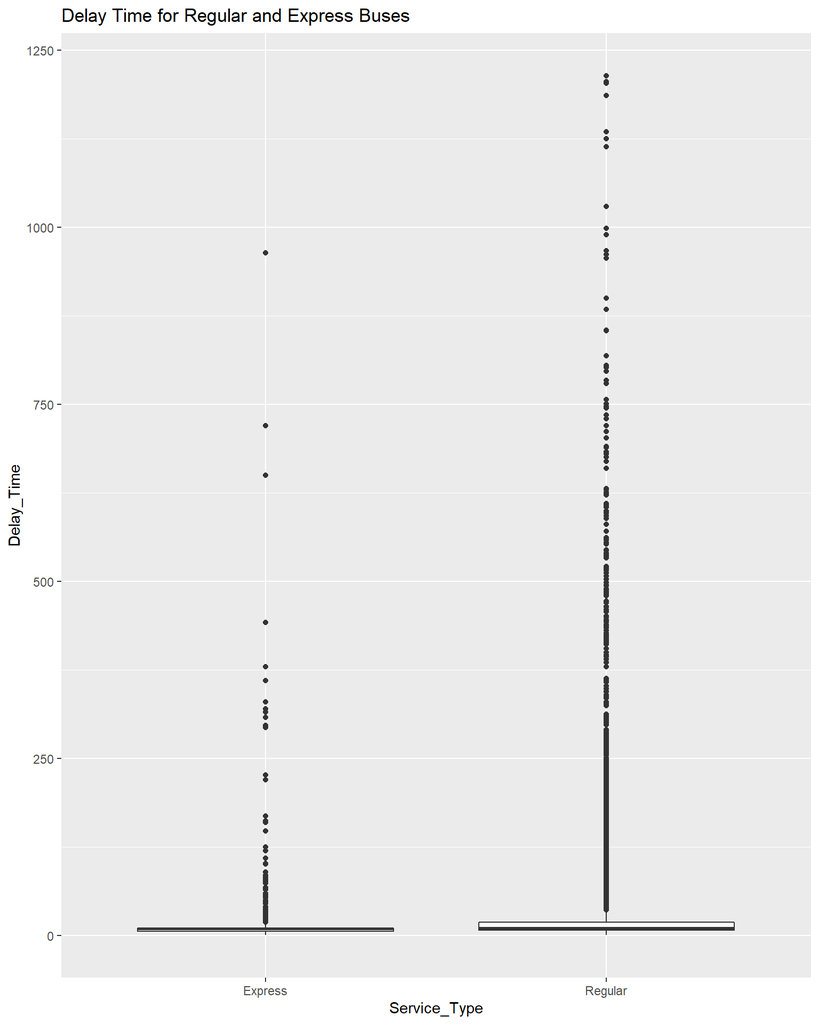

So far, it seems that the mean delay time for regular buses is larger than the mean delay times of the express buses. To determine the best statistical test, we’ll use Normal Quantile-Quantile plots to determine if the delay times are normally distributed.

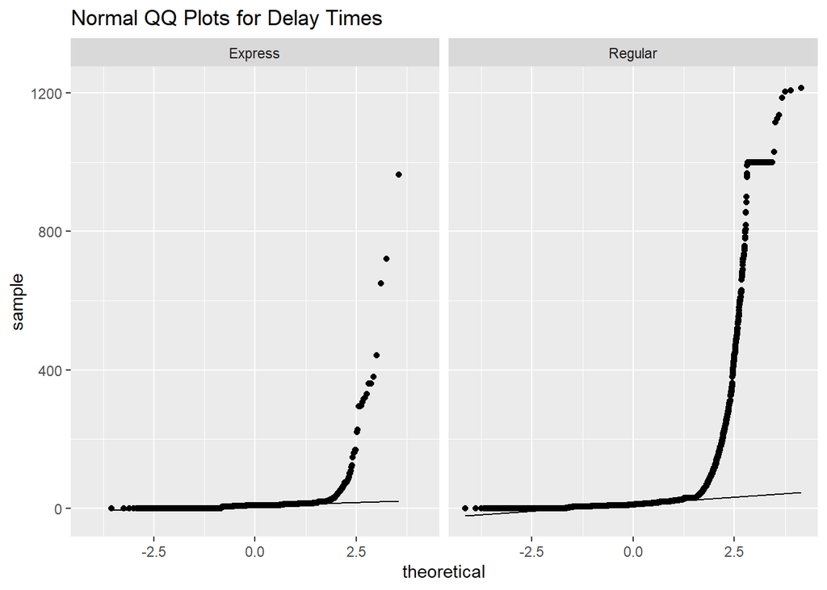

Since the points on the Normal QQ Plots do not follow a straight line, the Regular and Express buses’ Delay Times are skewed and do not follow a normal distribution. Since the data is not normally distributed, we will not use t-tests. Mood’s Median Test is more suitable, as it does not require the populations to be normally distributed. We will use Mood’s Median Test to see if the median Delay Time for the Regular buses is significantly higher than the median Delay Time for the Express buses. We’ll test the null hypothesis that the median Delay time for Regular buses is equal to the median Delay time for Express buses.

First we’ll find the median across both Express and Regular groups combined. Then we will see how many Regular bus delay times are greater than this median, and how many Express bus delay times are greater than this median. This gives us the following table.

```
##
## Service_Type FALSE  TRUE
##      Express  1978   621
##      Regular 15109 14129
```

From the table, we can see that nearly 76% of the Express bus delay times were below the median for the group with both types of buses. In contrast, only around 52% of the Regular bus delay times were below the median for Express and Regular buses.

We now run a two-sided Pearson chi-square test for testing the association between bus service type and whether delay times are higher than the median for both groups.

```
##
##  Pearson's Chi-squared test
##
## data:  types_table
## X-squared = 572.91, df = 1, p-value < 2.2e-16
```

Mood’s Median Test is a two-sided test, but if we want to consider the one-sided hypothesis that Regular bus Delay Times are greater than Express bus Delay Times, then we can consider half of the p-value. We can see that the p-value for the one-sided test is much smaller than $\alpha = 0.05$, the standard significance value used for testing.

Thus the median Delay Time for Regular buses was significantly larger than the median Delay Time for Express buses in 2020. It appears that Express bus arrival times were more reliable overall in 2020.

## Experiment with Chebyshev’s bound for Confidence Intervals

We could try using Chebyshev’s bound to come up with confidence intervals for the Regular bus and Express bus delay times. Chebyshev’s bound states that $1 - \frac{1}{k^2}$ percent of the distribution’s values are within $k$ standard deviations of the mean. By Chebyshev’s bound, 96% of a distribution’s values are 5 standard deviations away from the mean. So a 96% confidence interval would correspond to $(\bar{x} - 5s, \bar{x} + 5s)$ where $\bar{x}$ is the mean and $s$ is the standard deviation.

```
## # A tibble: 1 x 3
##   Regular_Mean Regular_SD CI_Regular
##          <dbl>      <dbl> <chr>
## 1         22.4       68.5 ( -319.985220959358 , 364.836305164844 )
```

```
## # A tibble: 1 x 3
##   Express_Mean Express_SD CI_Express
##          <dbl>      <dbl> <chr>
## 1         12.1       36.3 ( -169.506256442429 , 193.640923622113 )
```

We can see that the 96% confidence intervals generated by Chebyshev’s rule are quite large. When using Chebyshev’s rule to construct 95% confidence intervals, we need to include data up to 4.5 standard deviations away from the mean, but when the data is normal we can just include 2 standard deviations instead of 4.5. So Chebyshev’s bounds are less efficient compared to Gaussian bounds. Chebyshev’s bound gives very large estimates but it can be somewhat useful for instances where we can’t assume normality of the data.

## Effect Size

We have shown that there is a significant difference between the median delay times for Regular and Express buses. I would like to estimate the effect size, i.e. how much difference there is between the delay times of the Regular and Express buses. Usually Cohen’s d is used to express the effect size when the data is normal. However as we have seen from the Normal QQ plots, the bus delay data is not normal.

It turns out that since Mood’s median test is a type of chi-square test, we can express the effect sizes for Mood’s median test the same way we can express the effect sizes for chi-square tests. One way to express the effect size for a chi-square test on a $2 \times 2$ table is by computing the Phi coefficient $\varphi = \sqrt{\frac{\chi^2}{n}}$ where $\chi^2$ is the test statistic and $n$ is the total number of samples in the table.

```
## [1] "n"
```

```
## [1] 31837
```

```
## [1] "Chi-squared test statistic"
```

```
## X-squared
##  572.9089
```

```
## [1] "Phi coefficient for effect size of chi-square test"
```

```
## X-squared
## 0.1341457
```

We can see that $\varphi \approx 0.1341457$. We interpret $\varphi = 0.1$ as having a small effect, $\varphi = 0.3$ as having a medium effect, and $\varphi = 0.5$ as having a large effect, in accordance with Cohen’s 1988 book *Statistical Power Analysis for the Behavioral Sciences* (see pages 224-227). Using this scale, bus service type (Regular/Express) has a small effect on delay time being greater than the grand median.

Another way to express the effect size for a chi-square test on a $2 \times 2$ table is the odds ratio.

```
## $data
##
## Service_Type FALSE  TRUE Total
##      Express  1978   621  2599
##      Regular 15109 14129 29238
##      Total   17087 14750 31837
##
## $measure
##             odds ratio with 95% C.I.
## Service_Type estimate    lower    upper
##      Express 1.000000       NA       NA
##      Regular 2.977984 2.715161 3.270504
##
## $p.value
##             two-sided
## Service_Type midp.exact  fisher.exact   chi.square
##      Express         NA            NA           NA
##      Regular          0 1.477876e-133 1.30781e-126
##
## $correction
## [1] FALSE
##
## attr(,"method")
## [1] "median-unbiased estimate & mid-p exact CI"
```

We see that the odds of a regular bus having a delay time greater than the median is nearly 2.98 times the odds of an express bus having a delay time greater than the median.

# Delays in Eastbound/Westbound buses vs Northbound/Southbound buses

In the past, I have heard Toronto residents talk about how the public transit system in Toronto is designed to bring people into the downtown core in the south of the city (as evidenced by the subway map), and how it is better for North to South travel rather than East to West travel. Thus I am curious to see if Eastbound/Westbound buses usually experience longer delays than Northbound/Southbound buses.

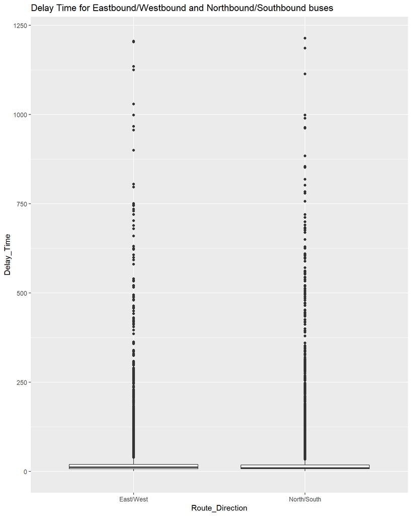

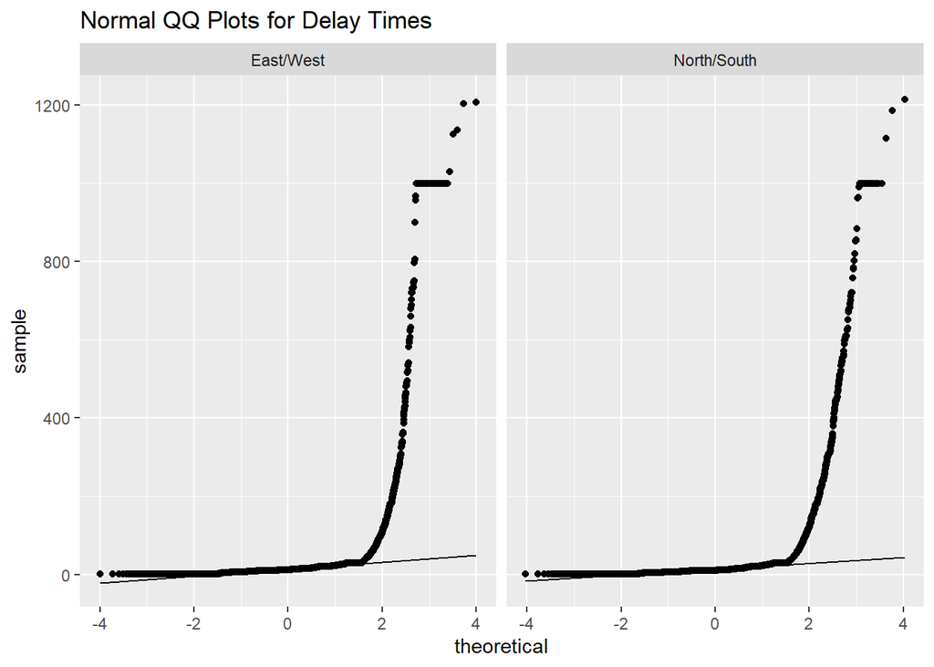

The East/West and North/South buses’ Delay Times do not follow normal distributions, because the points on the Normal QQ Plots do not follow straight lines. Since the data is not normally distributed, we will not use a t-test to compare the two groups. We’ll use Mood’s Median Test since that doesn’t require the delay times to be normally distributed. We’ll test the null hypothesis that the median Delay time for East/West buses is equal to the median Delay time for North/South buses. We will see if the median Delay Time for the East/West buses is significantly higher than the median Delay Time for the North/South buses.

First we’ll find the median across both Eastbound/Westbound and Northbound/Southbound groups combined. Then we will see how many Eastbound/Westbound bus delay times are greater than this median, and how many Northbound/Southbound bus delay times are greater than this median. This gives us the following table.

```
##
## Route_Direction FALSE  TRUE
##     North/South 10262  7352
##     East/West    7172  8256
```

We now run a Pearson chi-square test for testing the association between bus travel direction and delay time being greater than the median.

```
##
##  Pearson's Chi-squared test
##
## data:  dir_table
## X-squared = 457.41, df = 1, p-value < 2.2e-16
```

Mood’s Median Test is a two-sided test. If we want to consider the one-sided hypothesis that East/West bus Delay Times are greater than North/South bus Delay Times, then we can consider half of the p-value. We can see that the p-value for the one-sided test is much smaller than $\alpha = 0.05$, the standard significance value used for testing.

Thus the median Delay Time for East/West buses was significantly larger than the median Delay Time for North/South buses in 2020. It appears that North/South buses were more reliable overall in 2020. This does lend some credibility towards the residents’ notion that North/South travel is “better” than East/West travel in Toronto.

## Effect Size

We can express the effect size of the Mood’s median test using the Phi coefficient or the odds ratio, since Mood’s median test is a form of chi-square test.

```
## [1] "n"
```

```
## [1] 33042
```

```
## [1] "Chi-squared test statistic"
```

```
## X-squared
##  457.4102
```

```
## [1] "Phi coefficient for effect size of chi-square test"
```

```
## X-squared
## 0.1176575
```

We see that the Phi coefficient is around 0.1176575. We interpret $\varphi = 0.1$ as having a small effect, $\varphi = 0.3$ as having a medium effect, and $\varphi = 0.5$ as having a large effect, in accordance with Cohen’s 1988 book *Statistical Power Analysis for the Behavioral Sciences*. Using this scale, bus route direction has a small effect on delay time being greater than the grand median.

We will now find the odds ratio.

```
## $data
##
## Route_Direction FALSE  TRUE Total
##     North/South 10262  7352 17614
##     East/West    7172  8256 15428
##     Total       17434 15608 33042
##
## $measure
##                odds ratio with 95% C.I.
## Route_Direction estimate    lower   upper
##     North/South 1.000000       NA      NA
##     East/West   1.606718 1.538279 1.67831
##
## $p.value
##                two-sided
## Route_Direction midp.exact  fisher.exact    chi.square
##     North/South         NA            NA            NA
##     East/West            0 1.205166e-101 1.759889e-101
##
## $correction
## [1] FALSE
##
## attr(,"method")
## [1] "median-unbiased estimate & mid-p exact CI"
```

We see that the odds of an East/West bus having a delay time greater than the overall median is around 1.606718 times the odds of a North/South bus having a delay time greater than the overall median.

So there is a significant difference between the median delay times of North/South and East/West buses, but it is rather small.

# Incidents Causing Delays

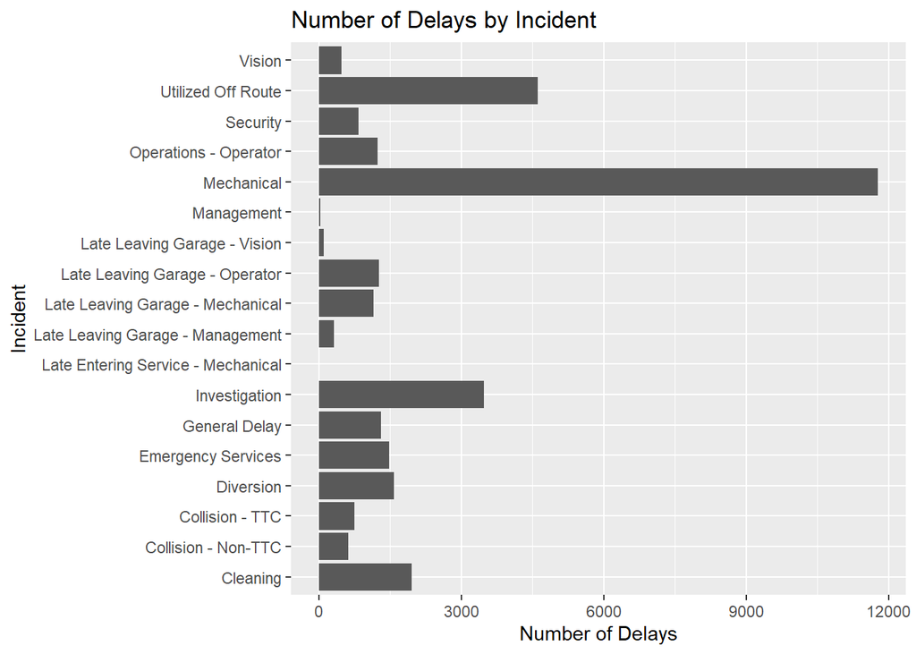

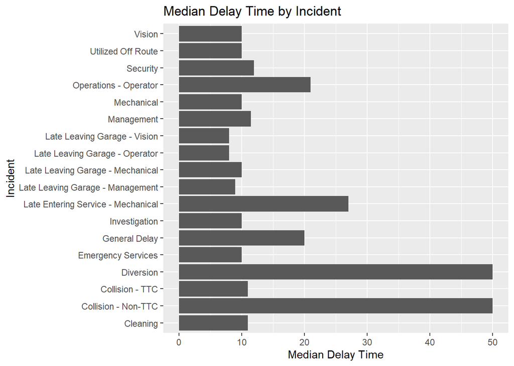

The most common cause of delay was mechanical issues, and on average, it resulted in a delay time of approximately 13 minutes.

The cause of delay that resulted in the longest average and median delay times was bus drivers using diversions from the specified routes, for example, due to road blockages caused by construction or traffic accidents. If the delay time was measured by how long it took for the bus to get to the stop on the original route, and the bus drivers were no longer able to get to the stop since the route changed, it would make sense that the delay times would be much longer.

## Delays Involving TTC vehicle Collisions vs Non-TTC vehicle Collisions

The cause of delay that resulted in the second longest average and median delay times was collisions of non-TTC vehicles causing road blockages. Interestingly, if a rider was expecting a delay due to a collision, if the collision was between non-TTC vehicles only, the average delay time was over 6 times that of a delay time caused by a collision involving a TTC vehicle. The median delay time was over 4 times that of a delay time caused by a collision involving a TTC vehicle. We do want to note that this is a result pertaining to what you can expect given that there is a delay caused by a collision, not what to expect when there is a collision.

Here we will see if there indeed is a statistically significant difference between the delay times for collisions involving TTC vehicles, and collisions not involving TTC vehicles.

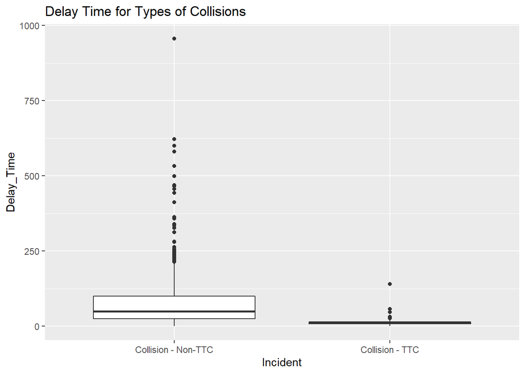

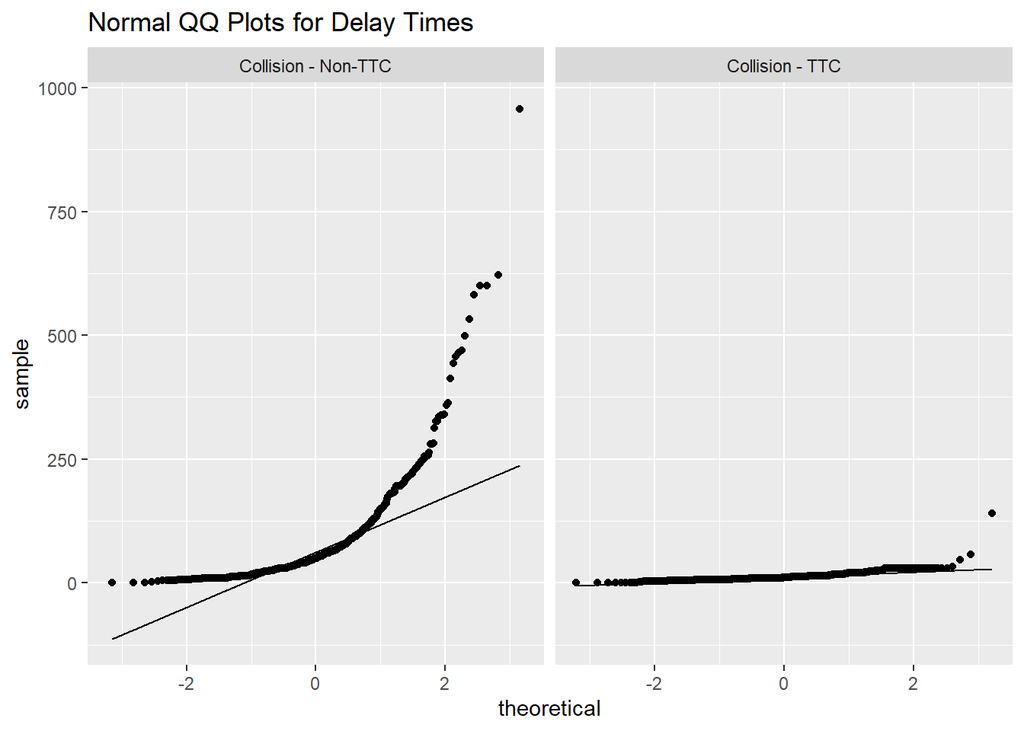

The delay time is not normally distributed among the Collision - Non-TTC group because the points on the Normal QQ Plot don’t follow a straight line.

First we’ll find the median across both Collision - TTC and Collision - Non-TTC groups combined. Then we will see how many TTC Collision delay times are greater than this median, and how many Non-TTC Collision delay times are greater than this median. This gives us the following table.

```
##
## Incident              FALSE TRUE
##   Collision - TTC       612  145
##   Collision - Non-TTC   104  514
```

Note that nearly 81% of TTC collision delay times are below the median across both groups, while nearly 17% of non-TTC delay times are below that threshold.

We now run a two-sided Pearson chi-square test for testing the association between Collision type and Delay Time being greater than overall median.

```
##
##  Pearson's Chi-squared test
##
## data:  collision_table
## X-squared = 558.7, df = 1, p-value < 2.2e-16
```

Mood’s Median Test is a two-sided test, but if we want to consider the one-sided hypothesis that Non-TTC Collision Delay Times are greater than TTC Collision Delay Times, then we can consider half of the p-value. We can see that the p-value for the one-sided test is much smaller than $\alpha = 0.05$, the standard significance value used for testing.

Thus the median Delay Time for delays caused by Non-TTC Collisions was significantly larger than the median Delay Time for delays caused by TTC Collisions in 2020.

## Effect Size

We can express the effect size of the Mood’s median test using the Phi coefficient or the odds ratio, since Mood’s median test is a form of chi-square test.

```
## [1] "n"
```

```
## [1] 1375
```

```
## [1] "Chi-squared test statistic"
```

```
## X-squared
##  558.7001
```

```
## [1] "Phi coefficient for effect size of chi-square test"
```

```
## X-squared
## 0.6374381
```

We see that the Phi coefficient is around 0.6374381. We interpret $\varphi = 0.1$ as having a small effect, $\varphi = 0.3$ as having a medium effect, and $\varphi = 0.5$ as having a large effect, in accordance with Cohen’s 1988 book *Statistical Power Analysis for the Behavioral Sciences*. Using this scale, whether the collision involves TTC vehicles or not has a large effect on delay time being greater than the grand median.

We will now find the odds ratio.

```
## $data
##
## Incident              FALSE TRUE Total
##   Collision - TTC       612  145   757
##   Collision - Non-TTC   104  514   618
##   Total                 716  659  1375
##
## $measure
##                      odds ratio with 95% C.I.
## Incident              estimate    lower    upper
##   Collision - TTC      1.00000       NA       NA
##   Collision - Non-TTC 20.77161 15.79577 27.53056
##
## $p.value
##                      two-sided
## Incident              midp.exact  fisher.exact    chi.square
##   Collision - TTC             NA            NA            NA
##   Collision - Non-TTC          0 5.704401e-133 1.612089e-123
##
## $correction
## [1] FALSE
##
## attr(,"method")
## [1] "median-unbiased estimate & mid-p exact CI"
```

We see that the odds of an bus delayed due to a Non-TTC Collision having a delay time greater than the overall median is around 20.77161 times the odds of a bus delayed due to a TTC Collision having a delay time greater than the overall median.

# Summary of Findings

- Routes with Most Delays: 52 Lawrence West, 32 Eglinton West, 133 Neilson
- Incident Causing Most Delays: Mechanical issues
- Incidents Causing Longest Delays on Average: Diversions, Non-TTC Collisions
- The median delay time for Regular buses was significantly higher than that of Express buses. Effect of bus service type on delay time being greater than median was small.
- The median delay time for East/West buses was significantly higher than that of North/South buses. Effect of route direction on delay time being greater than median was small.
- The median delay time for Non-TTC Collisions is significantly higher than that of TTC Collisions. Effect of collision type on delay time being greater than median was large.

# Work In Progress and Ideas for Further Avenues for Exploration

## Locations with the Most Delays

I have fixed inconsistencies in the spellings of many high-traffic Locations, however there are likely more that still need to be fixed. In particular, the Pearson Airport, Centennial College Loop, and U of T Scarborough locations still contain some inconsistencies. Premature experimentation suggests that Scarborough Centre Station and Kennedy Station likely experienced the most delays in 2020. So far, it seems like Subway Stations and Garages experience the highest number of delays. This would make sense since many mechanical repairs, cleaning are done by employees at these locations.

```
## # A tibble: 8,091 x 4
##    Location             `Number of Delays` `Average Delay Ti~ `Median Delay Tim~
##    <chr>                             <int>              <dbl>              <dbl>
##  1 SCARBOROUGH CENTRE ~               1309               11.1                 11
##  2 KENNEDY STATION                    1202               11.2                 10
##  3 EGLINTON STATION                    735               13.8                 12
##  4 WARDEN STATION                      734               14.0                 12
##  5 FINCH STATION                       696               11.1                  9
##  6 KIPLING STATION                     629               13.3                 11
##  7 PIONEER VILLAGE STA~                583               10.1                  9
##  8 YORK MILLS STATION                  548               16.4                 14
##  9 LAWRENCE WEST STATI~                510               16.2                 15
## 10 WILSON STATION                      371               14.5                 10
## # ... with 8,081 more rows
```

## Factors Influencing Delays at Subway Stations

So far, it seems that subway stations are the locations with the most delays. It would be interesting to gather additional data about these subway stations, and see why certain subway stations have more delays than others. Candidates to study include number of bus or streetcar routes connecting to the station, line number of subway, number of visitors per hour, and so on.

## When Do Most Delays Happen?

It’d be interesting to see what times, days and seasons experience the most delays. It would be interesting to download weather data and match it to the incidents by date and time. Then it may be interesting to see if low temperatures and/or high precipitation may be correlated with more mechanical repairs, collisions or diversions.

## Subway and Streetcar Delays

The TTC bus network is connected to its subway network and its streetcar network. It would be interesting to see if delays in the subway may affect delays in buses (eg due to increased passenger load) and vice versa. The TTC also posts datasets for Subway Delay Times and Streetcar Delay Times, so those would be interesting to explore.

## Impact of COVID-19 Service Cuts

I would like to run similar code on the data for other years and see if some of the results are just specific to the 2020 data. Due to the COVID-19 pandemic, the TTC had to cut service to many bus lines, in part due to decreased ridership during lockdowns. Many TTC employees working roles that involved facing the public were at high risk of contracting the COVID-19 virus. It is possible that many employees had to self-isolate during 2020, thus reducing the number of people available to drive buses and do repairs.

I wonder how such service changes may have affected the delay times of the buses. For example, would you expect more delays during a pandemic when there is less service, or would you expect more delays during non-pandemic times when there is more traffic? If I could find enough reliable information about TTC service in the TTC website’s News archives, I’d like to make another column containing information about frequency of bus service (eg how many minutes between arrival of consecutive buses). The TTC has also posted Next Vehicle Arrival Time datasets so that may be promising to explore.

## Model for Predicting Delay Time

I would like to create a model for predicting delay time. I would consider different regression models, feature selection on training/test sets using LASSO, and possibly more to see what variables are most predictive of delay time. Possible candidates include Direction, Location (eg. is it subway station, is it garage), frequency of service, Incident type, and more.

## Modelling Number of Delays Per Day as a Time Series

It may be interesting to model the number of delays per day as a time series, and do any necessary processing to ensure it is stationary. It may be interesting to try using the time series to predict how many delays there will be on a given day in the future. However, this will probably require processing and including the data over many years, not just the year 2020, to show any seasonal effects related to month.

# References

https://ttc.ca/routes-and-schedules#/

https://sharlagelfand.github.io/opendatatoronto/articles/articles/multisheet_resources.html

https://www.statology.org/replace-values-in-data-frame-r/

https://ritsokiguess.site/STAC33/notes.html

https://community.rstudio.com/t/understanding-the-use-of-str-replace-all-with-multiple-patterns/1849/2

https://open.toronto.ca/catalogue/?search=ttc&sort=score%20desc

https://www.publictransportation.org/transit-benefits/grows-communities/

https://towardsdatascience.com/what-if-your-data-is-not-normal-d7293f7b8f0

https://www.ncbi.nlm.nih.gov/pmc/articles/PMC2850938/

https://www.statology.org/effect-size-chi-square/

https://www.rdocumentation.org/packages/epitools/versions/0.5-10.1/topics/oddsratio

Cohen, J. (1988). *Statistical Power Analysis for the Behavioral Sciences, 2nd Edition.* Routledge.

Ellis, P. D. (2010). *The Essential Guide to effect sizes: Statistical Power, meta-analysis, and the interpretation of research results*. Cambridge University Press.